# Trp53cor1 KO vs WT (rmdup_liver)

# Gene/Pathway Analysis

## GSEA

Enrichment and zscores are calculated based on expression in KO vs WT (fpkmKO/fpkmWT), so genes that are down regulated in KO are shown in blue, while upregulation is shown in red.

KO/WT Blue = down in KO Red = Up in KO

Biocarta enrichment:

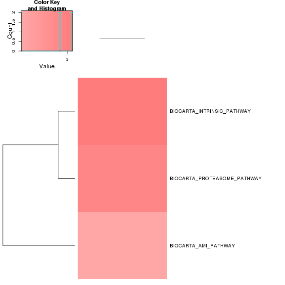

Biocarta zscore:

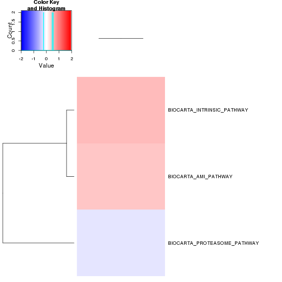

Reactome enrichment:

[output not shown]

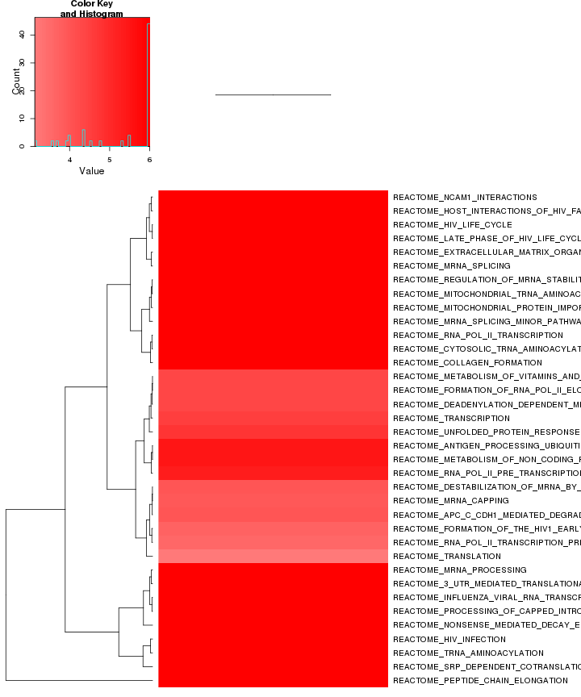

Reactome zscore:

[output not shown]

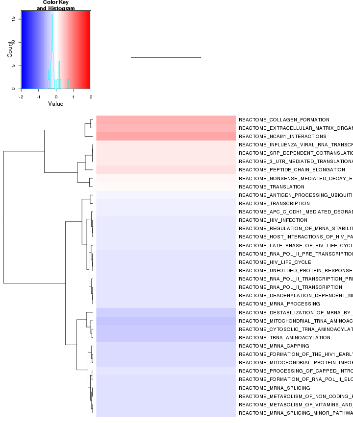

Kegg enrichment:

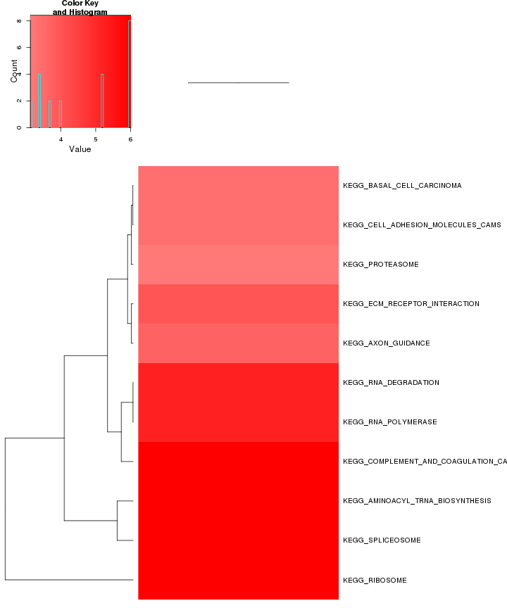

Kegg zscore:

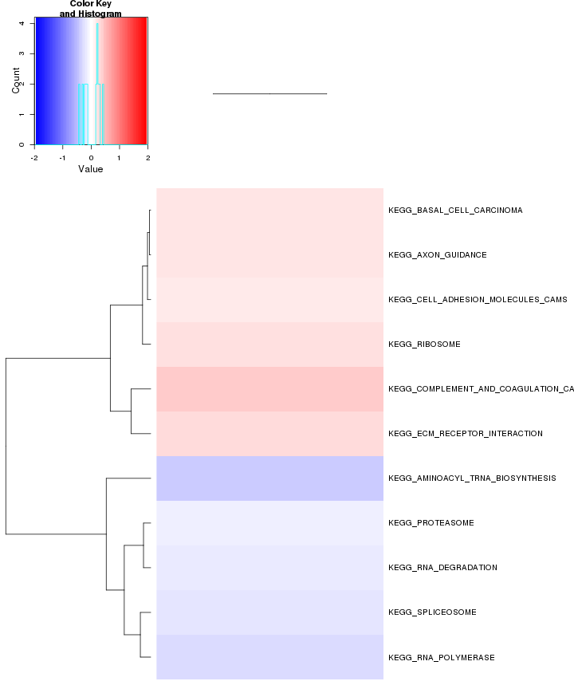

p53 enrichment:

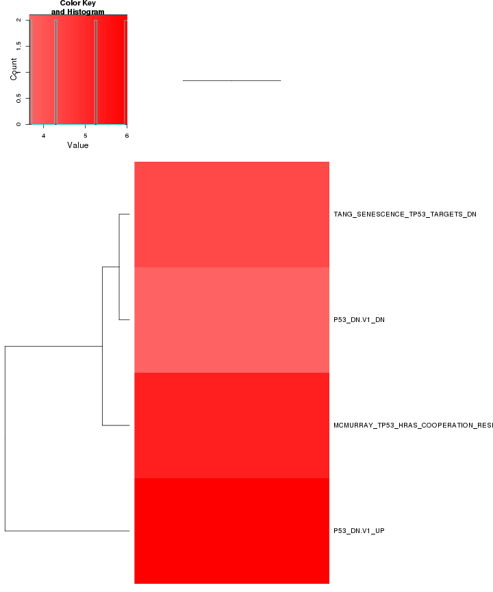

p53 zscore:

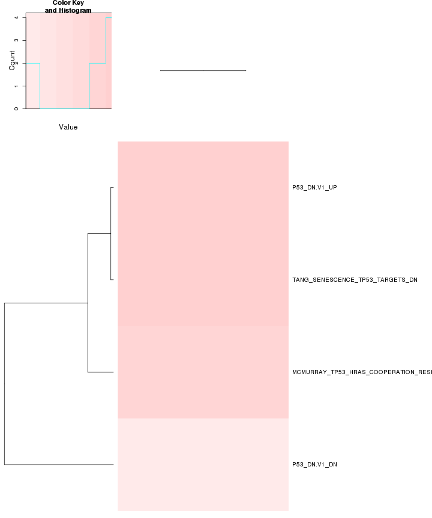

Oncogene enrichment:

[output not shown]

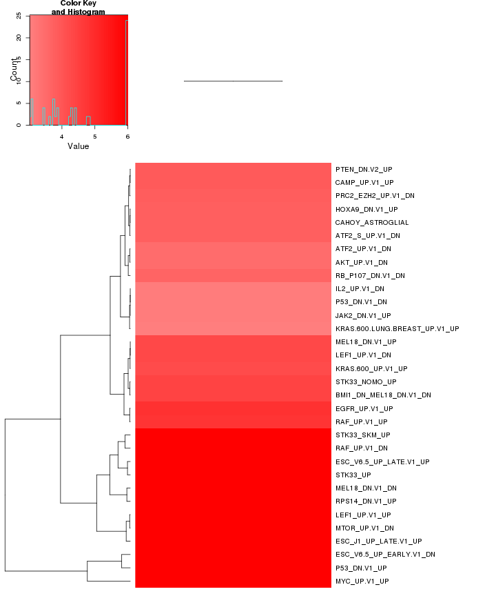

Oncogene zscore:

[output not shown]

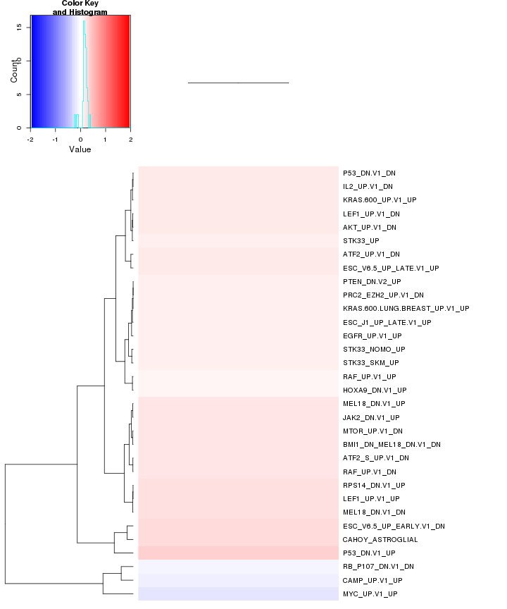

Jacks enrichment

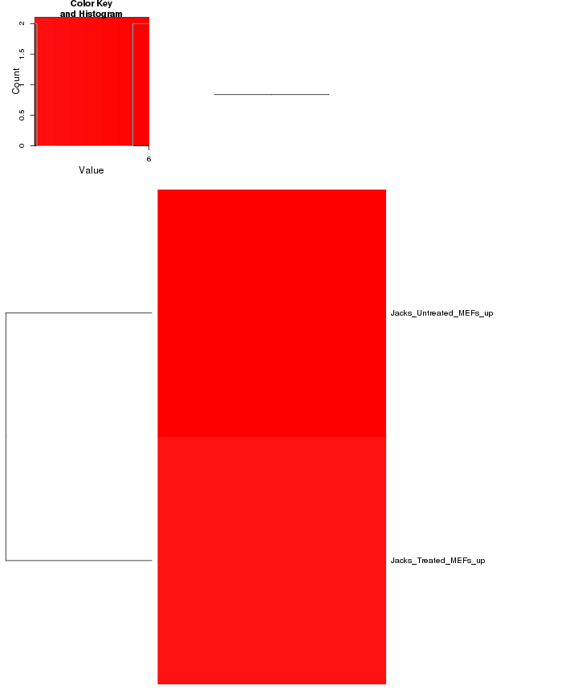

Jacks zscore

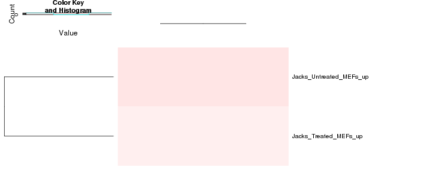

All enrichment

There are 998 categories enriched (p<0.0001). They are:

[output not shown]

[figure not shown]

ALL zscore:

[output not shown]

[figure not shown]

## GO enrichment

Cluster profiler used to call enichments of significantly differentially regulated genes that map to Entrez IDs.

[output not shown]

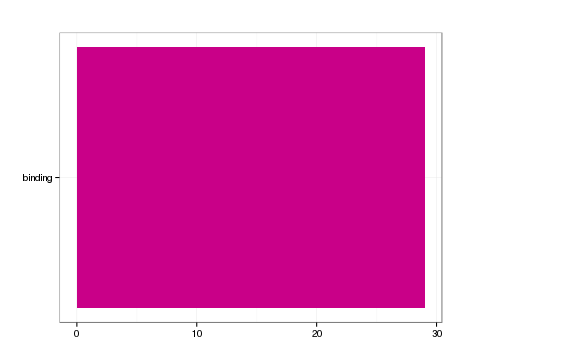

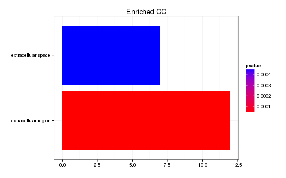

[output not shown]

[output not shown]

# Cis vs Trans (locally)

log2 Foldchange and test statistic are calculated with the ratio of fpkm(KO)/fpkm(WT), thus the test_stat is positive if a gene is higher in the KO and negative if a gene has lower expression in the KO

The pvalue for genes significantly regulated in a region this size is: 0.0099

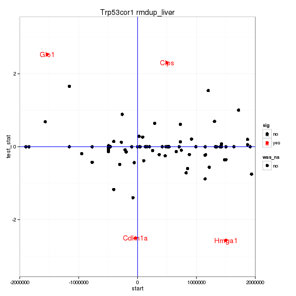

# Notes

## Samples used are:

|  | 11 |
| --- | --- |
| 1 | rmdup_JR917 |
| 2 | rmdup_JR925 |
| 3 | rmdup_JR933 |
| 4 | rmdup_liver_wt1 |
| 5 | rmdup_liver_wt2 |
| 6 | rmdup_JR926 |
| 7 | rmdup_JR934 |
| 8 | rmdup_liver_ko1 |
| 9 | rmdup_liver_ko2 |

## Replicates

|  | file | sample_name | replicate | rep_name | total_mass | norm_mass | internal_scale | external_scale |
| --- | --- | --- | --- | --- | --- | --- | --- | --- |
| 1 | /n/rinn_data1/users/agroff/seq/OtherMice/Diana/lincP21/quants/rmdup_JR917/abundances.cxb | WT | 0 | WT_0 | 27838900.00 | 20095000.00 | 1.47 | 1.00 |
| 2 | /n/rinn_data1/users/agroff/seq/OtherMice/Diana/lincP21/quants/rmdup_JR925/abundances.cxb | WT | 1 | WT_1 | 29269000.00 | 20095000.00 | 1.50 | 1.00 |
| 3 | /n/rinn_data1/users/agroff/seq/OtherMice/Diana/lincP21/quants/rmdup_JR933/abundances.cxb | WT | 2 | WT_2 | 24900300.00 | 20095000.00 | 1.30 | 1.00 |
| 4 | /n/rinn_data1/users/agroff/seq/OtherMice/Diana/lincP21/quants/rmdup_liver_wt1/abundances.cxb | WT | 3 | WT_3 | 17566300.00 | 20095000.00 | 0.83 | 1.00 |
| 5 | /n/rinn_data1/users/agroff/seq/OtherMice/Diana/lincP21/quants/rmdup_liver_wt2/abundances.cxb | WT | 4 | WT_4 | 14067100.00 | 20095000.00 | 0.65 | 1.00 |
| 6 | /n/rinn_data1/users/agroff/seq/OtherMice/Diana/lincP21/quants/rmdup_JR926/abundances.cxb | Trp53cor1 | 0 | Trp53cor1_0 | 28960900.00 | 20095000.00 | 1.62 | 1.00 |
| 7 | /n/rinn_data1/users/agroff/seq/OtherMice/Diana/lincP21/quants/rmdup_JR934/abundances.cxb | Trp53cor1 | 1 | Trp53cor1_1 | 22768700.00 | 20095000.00 | 1.22 | 1.00 |
| 8 | /n/rinn_data1/users/agroff/seq/OtherMice/Diana/lincP21/quants/rmdup_liver_ko1/abundances.cxb | Trp53cor1 | 2 | Trp53cor1_2 | 12384000.00 | 20095000.00 | 0.56 | 1.00 |
| 9 | /n/rinn_data1/users/agroff/seq/OtherMice/Diana/lincP21/quants/rmdup_liver_ko2/abundances.cxb | Trp53cor1 | 3 | Trp53cor1_3 | 12962900.00 | 20095000.00 | 0.60 | 1.00 |

## Run Info

[output not shown]